# Age-specific interactions

## Background

We can infer the age-specific effect of trait-variant association in various ways. How do they relate? e.g.

- Stratify individuals by age group and get the main effect
- Fit age as an interaction term
- 2-step linear model - get per-individual age slopes and intercepts, estimate genetic effects on slopes and parameters

Age isn’t a collider so stratifying shouldn’t introduce problems.

Approach - each individual has a growth curve with parameters that are genetically influenced. What happens when we age stratify using different methods?

```r
library(dplyr)
library(ggplot2)
library(lme4)

set.seed(1234)
```

Simulate data

```r
growth_curve2 <- function(x, phi1=20, phi2=-2.4, phi3=0.3) {
    g <- phi1 / (1 + exp(-(phi2 + phi3 * x)))
    g + rnorm(length(g), sd=g/(max(g)*10))
}

nid <- 50000

bg1 <- 5/2
bg2 <- 0.1/2
pg1 <- 0.3
pg2 <- 0.3

bmi <- lapply(1:nid, function(i) {
    tibble(
        id=i,
        g1 = rbinom(1, 2, pg1),
        g2 = rbinom(1, 2, pg2),
        age=sample(0:50, 20, replace=FALSE),
        value=growth_curve2(age, g1 * bg1 + rnorm(1, mean=23, sd=5), -2.4, g2 * bg2 + rnorm(1, mean=0.3, sd=0.1))
    ) %>% arrange(age)
}) %>% bind_rows()

str(bmi)
```

```
tibble [1,000,000 × 5] (S3: tbl_df/tbl/data.frame)
 $ id   : int [1:1000000] 1 1 1 1 1 1 1 1 1 1 ...
 $ g1   : int [1:1000000] 0 0 0 0 0 0 0 0 0 0 ...
 $ g2   : int [1:1000000] 1 1 1 1 1 1 1 1 1 1 ...
 $ age  : int [1:1000000] 3 4 5 8 13 14 15 20 21 25 ...
 $ value: num [1:1000000] 4.03 4.72 5.49 8.35 14.52 ...
```

Example of what simulated data looks like

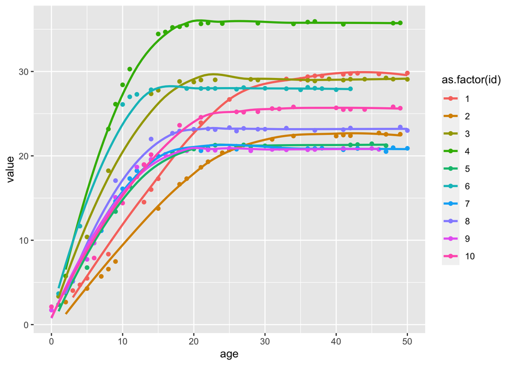

```r
ggplot(bmi %>% filter(id < 11), aes(x=age, y=value)) +
geom_point(aes(colour=as.factor(id))) +
geom_smooth(aes(colour=as.factor(id)), se=FALSE)
```

Stratifying by age, and getting main effect in each stratum

```r
o <- lapply(unique(bmi$age), function(a) {
  x <- subset(bmi, age == a) %>% slice_sample(n=1000)
  print(dim(x))
  r <- bind_rows(
    summary(lm(value ~ g1, x))$coef %>% as_tibble() %>% mutate(g=1) %>% slice_tail(n=1),
    summary(lm(value ~ g2, x))$coef %>% as_tibble() %>% mutate(g=2) %>% slice_tail(n=1)
  )
  names(r) <- c("beta", "se", "tval", "pval", "g")
  r$age <- a
  return(r)
}) %>% bind_rows()
```

[output not shown]

[output cut: 36 more lines]

```r
o
```

| beta | se | tval | pval | g | age |
| --- | --- | --- | --- | --- | --- |
| 0.57794118 | 0.07528399 | 7.67681364 | 3.876186e-14 | 1 | 3 |
| 0.65340821 | 0.07504633 | 8.70673112 | 1.277175e-17 | 2 | 3 |
| 0.48116253 | 0.11436847 | 4.20712577 | 2.819179e-05 | 1 | 4 |
| 1.07693225 | 0.11740096 | 9.17311294 | 2.566741e-19 | 2 | 4 |
| 1.13404272 | 0.16403968 | 6.91322191 | 8.442383e-12 | 1 | 5 |
| 1.45769320 | 0.16348333 | 8.91646408 | 2.250297e-18 | 2 | 5 |
| 1.58677532 | 0.25703309 | 6.17342810 | 9.707135e-10 | 1 | 8 |
| 1.66766293 | 0.25013809 | 6.66696929 | 4.315211e-11 | 2 | 8 |
| 2.51673335 | 0.28570796 | 8.80876168 | 5.511940e-18 | 1 | 13 |
| 1.39942599 | 0.29722022 | 4.70838088 | 2.849599e-06 | 2 | 13 |

[output cut: 92 more lines]

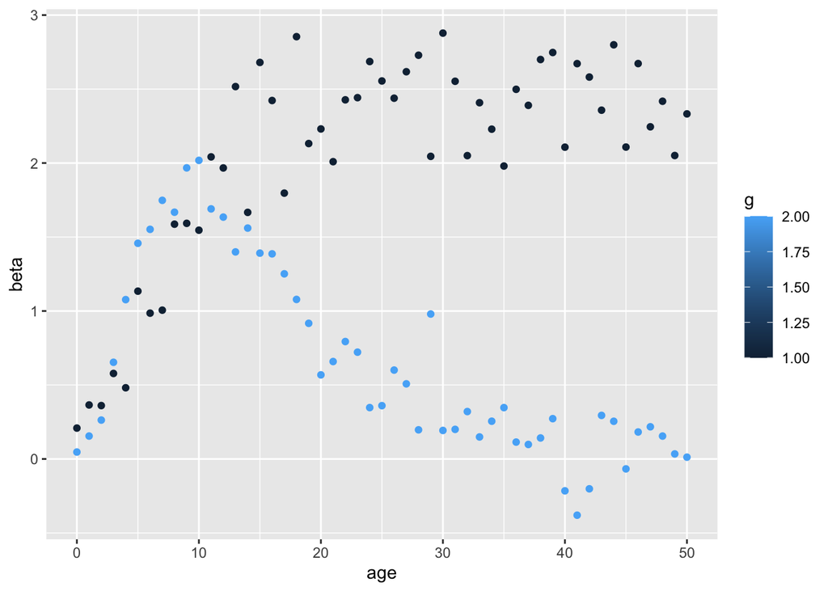

```r
ggplot(o, aes(y=beta, x= age)) +
  geom_point(aes(colour=g))
```

Makes sense because g1 influences the asymptote, and g2 influences the rate of growth.

Interaction with main effect - does it give the same thing?

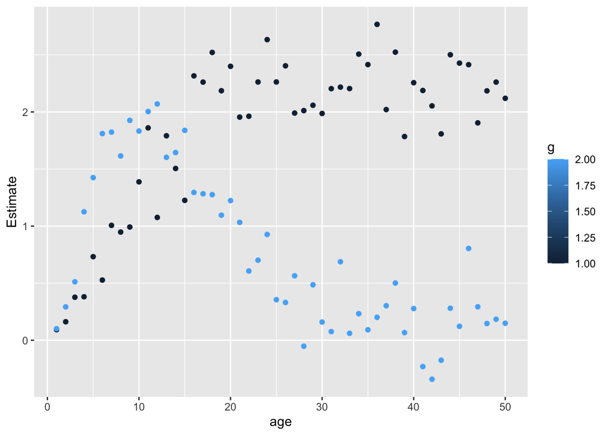

```r
oi1 <- bmi %>% group_by(id) %>%
  slice_sample(n=1) %>%
  {summary(lm(value ~ g1 * as.factor(age), .))$coef}
oi2 <- bmi %>% group_by(id) %>%
  slice_sample(n=1) %>%
  {summary(lm(value ~ g2 * as.factor(age), .))$coef}
oi1 <- bind_cols(p = rownames(oi1), oi1) %>% as_tibble %>% filter(grepl("g1:", p)) %>% mutate(age=gsub("g1\\:as.factor\\(age\\)", "", p) %>% as.numeric(), g=1)
oi2 <- bind_cols(p = rownames(oi2), oi2) %>% as_tibble %>% filter(grepl("g2:", p)) %>% mutate(age=gsub("g2\\:as.factor\\(age\\)", "", p) %>% as.numeric(), g=2)

ggplot(bind_rows(oi1, oi2), aes(y=Estimate, x=age)) +
  geom_point(aes(colour=g))
```

Linear model for each individual

```r
temp <- bmi %>% filter(id %in% 1:1000)
a <- lmer(value ~ age + (1+age|id), data=temp)
b <- ranef(a)
head(b$id)
```

|  | (Intercept) | age |
| --- | --- | --- |
| 1 | -3.11384947 | 0.164278524 |
| 2 | -4.39460900 | 0.033832734 |
| 3 | 4.75739472 | -0.012807851 |
| 4 | 11.70591067 | 0.013564999 |
| 5 | -0.06871647 | -0.050490788 |
| 6 | 5.65167436 | -0.005632972 |

```r
rbind(
    summary(lm(b$id[,1] ~ temp$g1[!duplicated(temp$id)]))$coef[2,],
    summary(lm(b$id[,2] ~ temp$g1[!duplicated(temp$id)]))$coef[2,],
    summary(lm(b$id[,1] ~ temp$g2[!duplicated(temp$id)]))$coef[2,],
    summary(lm(b$id[,2] ~ temp$g2[!duplicated(temp$id)]))$coef[2,]
)
```

```
        Estimate  Std. Error   t value     Pr(>|t|)
[1,]  1.05784708 0.194558484  5.437168 6.807184e-08
[2,]  0.02622162 0.004303497  6.093097 1.579452e-09
[3,]  1.30851566 0.195321406  6.699295 3.493596e-11
[4,] -0.02265172 0.004374294 -5.178370 2.706779e-07
```

### Summary

- Stratifying by age gives same result as fitting age as an interaction - provided that interaction includes main effects for snp and age
- Linear model still picks things up

## Experiment - interactions with a collider

If there is a binary variable that is a collider, does it make a difference if it is tested stratified or as an interaction term

note this isn’t an issue for age which can’t be a collider

```r
n <- 10000
x <- rnorm(n)
y <- rnorm(n)
u <- x + y + rnorm(n)
C <- rbinom(n, 1, plogis(u))
summary(lm(y ~ x, subset=C==1))$coef[2,1]
```

```
[1] -0.1274305
```

```r
summary(lm(y ~ x, subset=C==0))$coef[2,1]
```

```
[1] -0.1197606
```

```r
summary(lm(y ~ x))$coef[2,1]
```

```
[1] 0.003735308
```

```r
summary(lm(y ~ x * as.factor(C)))
```

```
Call:
lm(formula = y ~ x * as.factor(C))

Residuals:
    Min      1Q  Median      3Q     Max
-3.6992 -0.6213 -0.0028  0.6146  3.3290

Coefficients:
                Estimate Std. Error t value Pr(>|t|)
(Intercept)     -0.37280    0.01379 -27.034   <2e-16 ***
x               -0.11976    0.01423  -8.415   <2e-16 ***
as.factor(C)1    0.74257    0.01964  37.802   <2e-16 ***
x:as.factor(C)1 -0.00767    0.01993  -0.385      0.7
---
Signif. codes:  0 '***' 0.001 '**' 0.01 '*' 0.05 '.' 0.1 ' ' 1

Residual standard error: 0.9241 on 9996 degrees of freedom
Multiple R-squared:  0.1251,    Adjusted R-squared:  0.1248
F-statistic: 476.5 on 3 and 9996 DF,  p-value: < 2.2e-16
```

```r
summary(lm(y ~ x : as.factor(C)))
```

```
Call:
lm(formula = y ~ x:as.factor(C))

Residuals:
    Min      1Q  Median      3Q     Max
-4.0158 -0.6645 -0.0068  0.6616  3.2348

Coefficients:
                 Estimate Std. Error t value Pr(>|t|)
(Intercept)     -0.006836   0.010499  -0.651    0.515
x:as.factor(C)0  0.009325   0.014769   0.631    0.528
x:as.factor(C)1 -0.001655   0.014488  -0.114    0.909

Residual standard error: 0.988 on 9997 degrees of freedom
Multiple R-squared:  4.045e-05, Adjusted R-squared:  -0.0001596
F-statistic: 0.2022 on 2 and 9997 DF,  p-value: 0.8169
```

## Summary

- interaction with a collider is a problem as expected